# Exercises – Additional: Simulating Distributions and Assessing Inferential Risks in Clustering

*Basics of Python for Data Science*

## Scenario

In the previous exercise, you learned how to use *K-Means* and *GMM* for unsupervised clustering. Now, your task is to assess whether clustering results are robust across different scenarios involving correlated variables, heterogeneous variances, non-normal distributions, and varying numbers of true underlying clusters (`k`). In other words, you will **simulate data** under a range of **assumption violations** (e.g., correlated features, unequal variances, non-Gaussian distributions), and then apply clustering methods to see whether they still:

- Correctly identify the number of underlying clusters;
- Provide accurate classification (e.g., as evaluated using the *Adjusted Rand Index*).

## Suggestions

### Simulating correlated, skewed, and heteroscedastic variables

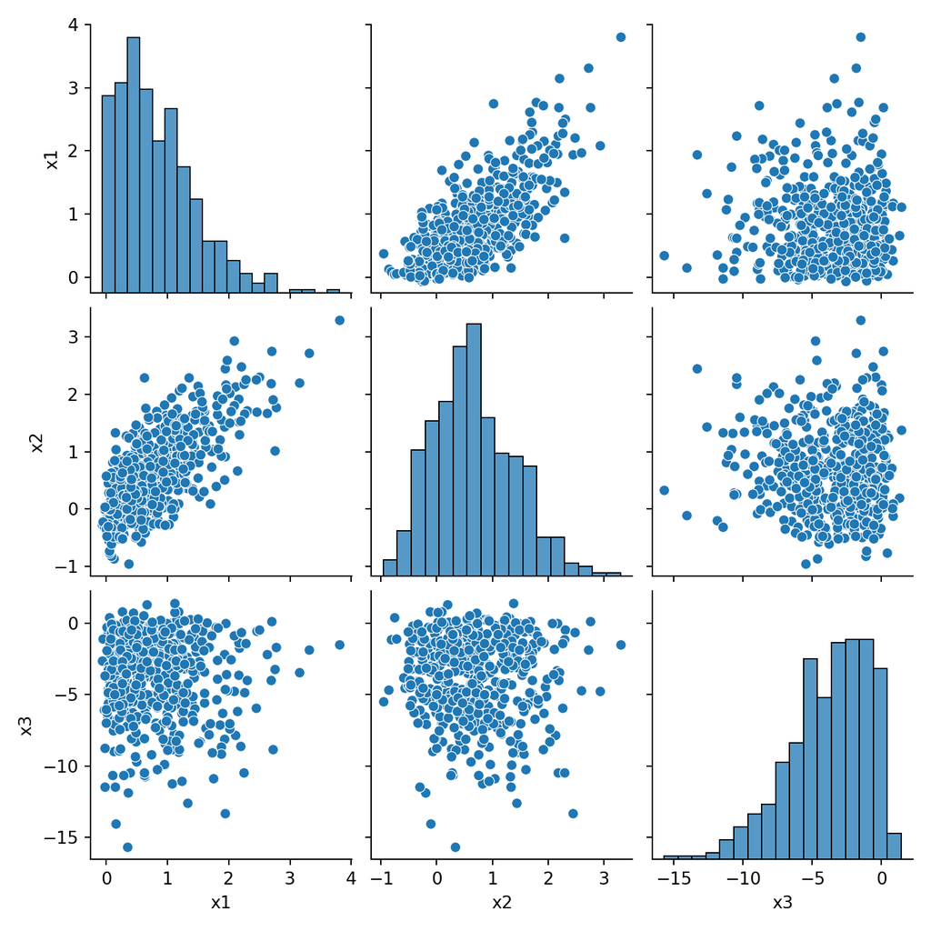

```python
import numpy as np
import pandas as pd
import seaborn as sns
import matplotlib.pyplot as plt
from scipy.stats import skewnorm

# set desired sample size
N = 500

# Create a strongly positively skewed variable
x1 = skewnorm.rvs(a=20, loc=0, scale=1, size=N)

# Create a normally distributed variable highly correlated with x1
x2 = 0.8*x1 + np.random.normal(0, 0.5, size=N)

# Create a third negatively skewed variable with much higher variance
x3 = skewnorm.rvs(a=-5, loc=0, scale=5, size=N)

# Combine into a DataFrame
df = pd.DataFrame({'x1': x1, 'x2': x2, 'x3': x3})

# Pairplot to visualize relationships
sns.pairplot(df);
plt.show(); plt.close()
```

### Simulating more than one true component

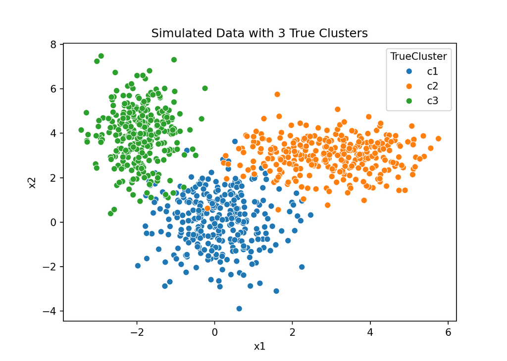

```python
# Simulate 3 clusters (with 2-D features, but only to facilitate visualization)
n = 300

# generate three different clusters and combine them in a single 2-D array
c1 = np.random.normal(loc=[0, 0], scale=[0.9, 1.4], size=(n, 2))
c2 = np.random.normal(loc=[3, 3], scale=[1.2, 0.8], size=(n, 2))
c3 = np.random.normal(loc=[-2, 4], scale=[0.6, 1.3], size=(n, 2))
x = np.vstack([c1, c2, c3])

# generate a dataframe in DataFrame and add labels of true cluster
df = pd.DataFrame(x, columns=["x1", "x2"])
df["TrueCluster"] = ["c1"]*n + ["c2"]*n + ["c3"]*n

# Scatter plot with color by true cluster label
sns.scatterplot(data=df, x="x1", y="x2", hue="TrueCluster")
plt.title("Simulated Data with 3 True Clusters")
plt.xlabel("x1")
plt.ylabel("x2")
plt.show()
```

### Example of (Adjusted) Rand Index

The following example on the calculation of the Rand Index is applied the `df` dataframe with 3 true clusters simulated in the previous chunk

```python
# import packages and functions as needed
from sklearn.cluster import KMeans
from sklearn.metrics import adjusted_rand_score

# Fit K-Means clustering with k=3
kmeans = KMeans(n_clusters=3)
predicted_labels = kmeans.fit_predict(df[["x1","x2"]])

# Compute Adjusted Rand Index
ari = adjusted_rand_score(df["TrueCluster"], predicted_labels)
print(round(ari,4))
```

```
0.8965
```

*Note:* The Adjusted Rand Index (ARI) ranges from -1 to 1, with **1** indicating perfect agreement between the predicted and the true cluster labels, and **0** indicating that the agreement is at chance level (i.e., worst possible performance). Non-adjusted Rand Index, on the contrary, would have `1 / number_of_clusters` as the chance level (in the case above, it would have been `0.333`).